# Recognition of Pre-Modern Japanese by Scratch-Built CNN

## Contents

I. INTRODUCTION

II. MOTIVATION

III. INSTRUCTIONS

IV. METHODS

V. RELATED WORK

VI. DESCRIPTION

VII. DISCUSSION

VIII. FUTURE WORK

## Code Contents

A. LOAD DATA

B. FORWARD PASS

C. BACKWARD PASS

D. RUN NETWORK

E. RESULTS

🢃

### Introduction

Top

Written Japanese uses a mixed-script system: *kanji*—[morphographic](http://www.ingentaconnect.com/content/jbp/wll/2011/00000014/00000001/art00004) Chinese characters, which is to say: graphemes that mainly represent the morphemes used in word formation—and derived from these, there are two types of phonographic *kana*, which are simpler graphemes representing only the Japanese sound system’s moraic syllable (e.g., ‘*ka*’) foundation, used mostly for grammatical functions.

[figure not shown]

*Figure 1: A text containing archaic handwritten Japanese, [via](http://www.asahi.com/ajw/articles/AJ201612090010.html)*

Handwritten Japanese before the 19c standardizations of the Meiji era is characterized by myriad, idiosyncratic variations of *kanji* and *kana* (*hentaigana*), collectively called *kuzushiji*, and has thereby limited primary access to pre-modern corpora to the few who have attained the necessary literacy (Hashimoto, et al., [2017](http://digitalhumanities.org/dhq/vol/11/1/000281/000281.html)).

Given the value of the historical record, deciphering *kuzushiji* is a significant [enterprise](https://guides.library.upenn.edu/japanesedigitalresources/kuzushiji), enabled by scanning images of historical texts, with scholars painstakingly hand-labeling characters. A typical practice is training computational models to classify characters, trial-and-error supervised with expert labels acting as the ‘ground truth,’ for corrective feedback. Examples of applications for this topic range from [adapting Edo period recipes](http://www.asahi.com/ajw/articles/AJ201612090010.html) to gathering [seismological](http://www.kyoto-u.ac.jp/cutting-edge/continuum/page01.html) data to better predict earthquakes.

Deep neural networks are state-of-the-art in image recognition, with multiple layers of interconnected ‘neurons’ leveraged to learn numeric representations of training data (e.g., a subset of character images extracted from a corpus, and their manually coded target labels), which can be generalized to evaluate new data (e.g., classifying a novel subset of images and targets).

For image tasks, the standard architecture is the convolutional neural network (CNN). The key feature of its effectiveness is that a CNN retains the spatial relationships of the pixels comprising images, rather than flattening inputs at the onset.

[figure not shown]

*Figure 2: A typical convolutional neural network, [via](https://www.mathworks.com/discovery/convolutional-neural-network.html)*

[TensorFlow](https://www.tensorflow.org/) is a high-level library known for providing prefab functions executed over the abstraction of a computational graph. It is an accessible resource which allows diverse researchers to employ deep learning without attending to low-level details (e.g., convolutional operations).

### Motivation

Top

Nominally, the aim of this project—originally for DePaul University's [CSC 578](http://reed.cs.depaul.edu/peterh/class/csc578/), Fall 2017, and very much a work in progress—is *kuzushiji* recognition with a convolutional neural network: the approach taken was to work within TensorFlow, but implementing the network from scratch, rather than using pre-built operations: to explicitly code such low-level components as the multiplication of tensor data structures by functions for convolution and subsampling, and arranging the data and control flow over bespoke forward and backward layering.

The primary purpose was self-directed learning. Building the network from scratch in TensorFlow, as opposed to NumPy or Octave, provided unique opportunities: to gain insight into the computational graph as a framework and to practice manipulating high-dimensional tensors, with the TensorFlow ecology acting as a kind of scaffolding for deconstructing pre-existing code.

The focus on classifying calligraphy enabled working with meaningful data in a [generative](https://link.springer.com/article/10.1007/s10648-015-9348-9) exercise, motivating intensive practice with fundamentals. This includes the nuanced challenges and rewards of preprocessing multicultural artifacts.

Due to the workload and bugs introduced with this scratch-built, *ad hoc* approach and a good measure of domain ignorance, this implementation adheres to mostly vanilla structures in order to ease fine-tuning of the hyperparameters and focus on learning important aspects of CNNs.

### Instructions

Top

Datasets can be downloaded from the CODH [website](http://codh.rois.ac.jp/char-shape/book/) ([CC BY-SA 4.0](https://creativecommons.org/licenses/by-sa/4.0/)). The *char dirs* path can be modified in the Load Data cell to point to the location of the unzipped archive's '/characters' folder. Once this is done, one may simply run the notebook.

This cell also contains variables for truncating the number of image files to be used, the batch size, convolutional layer's stride, dimensions, and number of feature maps. Other parameters and hyperparameters may be adjusted in the Run Network cells. By default, the regularization parameter λ is scaled according to Nielsen's [description](http://neuralnetworksanddeeplearning.com/chap3.html#MathJax-Element-389-Frame), to ensure the weight decay gives enough regularization for larger training sets.

Results are displayed in the Results section, and may be printed to file; TensorBoard can be used to visualize the results.

### Methods

Top

Following a standard template, the architecture consists of two convolutional and subsampling layer pairs, followed by a pair of affine layers. Non-linearities for the convolutional layers use an explicitly defined function for leaky rectified linear units (LReLU): the leaky version of this transfer function (intended to prevent the problem of exponentially decreasing gradients) mitigates the issue of cell death in standard ReLU by allowing for a minimal gradient in the negative case, rather than thresholding at zero. The convolutions are downsampled with conventional max-pooling.

[figure not shown]

*Figure 3: Sample TensorBoard visualization*

Dropout (Srivastava, et al., [2014](https://dl.acm.org/citation.cfm?id=2670313)) is applied to the first affine layer, also from scratch: dropout reduces neuronal co-adaptations by forcing cells to adapt to the more diverse ecologies created by randomly mutated subsets of a network, creating a robust combined model with more independent feature units.

Finally, the readout layer outputs are sent directly to an explicit softmax function with negative log-likelihood loss, to obtain and evaluate a probability distribution for the appropriate class labels. This function is defined such that it scales the logits before normalization, to avoid underflow and overflow, per a best practice referenced by Goodfellow, et al. ([2016](http://www.deeplearningbook.org/contents/numerical.html)) (+[ja](https://www.deeplearningbook.me/)).

Weight decay via L2 regularization is used to help the model better discover underlying patterns in the data with less sensitivity to local noise. Momentum is used with gradient descent, titrating the “velocity” through “friction” rather than merely “force” (the gradient). Of final note, the training phase employs early-stopping based on the validation set accuracy, aborting when this saturates.

### Related Work

Top

*Figure 4: Example of Neocognitron Architecture via [doi:10.4249/scholarpedia.1717](http://dx.doi.org/10.4249/scholarpedia.1717)*

[figure not shown]

The ancestor of the modern convolutional neural network with its use of biologically inspired receptive fields is the Neocognitron (Fukushima, [1980](http://www.scholarpedia.org/article/Neocognitron)). Recently, the Neocognitron was used in the recognition of *hentaigana* (Hayasaka, et al., [2015](https://www.jstage.jst.go.jp/article/toyotakosenkiyo/48/0/48_KJ00010158360/_article)), before the authors implemented the task using a CNN (Hayasaka, et al., [2016](https://ipsj.ixsq.nii.ac.jp/ej/index.php?active_action=repository_view_main_item_detail&page_id=13&block_id=8&item_id=176212&item_no=1)), and created an online [app](http://vpac.toyota-ct.ac.jp/hayasaka/kuzushiji/). The latter project appears to have used Python 2.7; a Matlab-based CNN has also been used for *hentaigana* (Agata, [2017](https://www.mathworks.com/matlabcentral/fileexchange/62682-cnn-for-old-japanese-character-classification)), as well as a high-level Keras transfer of ResNet-50 (Hataya, [2017](https://github.com/moskomule/kuzushi-ji)). Prior to this, a modular neural networks approach with [Self-Organizing Maps](http://www.springer.com/us/book/9783540679219) was described (Horiuchi & Kato, [2009](https://www.semanticscholar.org/paper/A-Study-on-Japanese-Historical-Character-Recogniti-Horiuchi-Kato/0046e8d07f344ae28dd5ea08fce1db7abc9855b2)).

### References

Top

*Figure 5: Data processing via [CODH](http://codh.rois.ac.jp/)*

[figure not shown]

The primary references for this project were Michael Nielsen’s free online book, [*Neural Networks & Deep Learning*](http://neuralnetworksanddeeplearning.com/) (+[ja](http://nnadl-ja.github.io/nnadl_site_ja/index.html)) and the many notes and assignment code (Python/NumPy) for the online course, [CS231N](http://cs231n.github.io\convolutional-networks\) (Andrej Karpathy, et al.), with additional references to general TensorFlow [tutorials](https://www.tensorflow.org/tutorials/mnist/pros/#deep-mnist-for-experts) and documentation. More detailed references can be found in the various Jupyter Notebook markdown cells and code comments.

Character data was procured from the open access sets provided by 人文学オープンデータ共同利用センター (Center for Open Data in the Humanities / [CODH](http://codh.rois.ac.jp)).

Specifically the respective fiction and poetry from:

- [*Tales of Moonlight and Rain (雨月物語)*](http://codh.rois.ac.jp/char-shape/book/200014740/) by [Ueda Akinari](https://en.wikipedia.org/wiki/Ueda_Akinari) (上田 秋成, July 25, 1734 – August 8, 1809)
- [*My Spring (おらが春)*](http://codh.rois.ac.jp/char-shape/book/200003967/) by [Kobayashi Issa](https://en.wikipedia.org/wiki/Kobayashi_Issa) (小林 一茶, June 15, 1763 – January 5, 1828)

With these data sets, after being extracted from scanned books, image files for each character are contained in folders labeled according to the character’s corresponding Unicode code point, as listed [here](http://codh.rois.ac.jp/char-shape/unicode/).

### Description

Top

We begin with the data loading and preprocessing as described in their sections, define the variables and functions for the forward (per the architecture above) and backward (backpropagation, stochastic gradient descent with L2 regularization and momentum) passes, and run the network over the training, validation, and testing mini-batches with early-stopping, logging the results for TensorBoard and finally printing sample imagery.

```python
import heapq
import numpy as np
import os, cv2, h5py
import tensorflow as tf
import matplotlib.pyplot as plt
from tqdm import tqdm_notebook
from sklearn.utils import shuffle
from sklearn.model_selection import train_test_split
```

### Load Data

Top

Japanese character data loading and preprocessing.

```python
tf.reset_default_graph()

# =====================================
flist = []
labels = []
layers = ['conv_relu1', 'pool1', 'conv_relu2',
          'pool2', 'fc1_relu_dropout', 'fc2_readout']
parameters = []
velocities = []
caches = []
rs = 42 # random state
patience = 3
delta = 0.02 # accuracy improvement criterion for early-stopping
impatience = 0
best = -np.Inf
num_epochs = 2
save_model_path = './kuzushijinn/model.ckpt'
ih, iw = 28, 28 # dimensions
c = 1 # channels
trunc = 2000 # number of image samples to limit
char_dir = 'c:/datasets/brsk00000/characters'
# char_dir = 'C:/datasets/200003967/characters'
batch_size = 50
kf = 3 # (height/width), F
fm = 32
fm2 = 64
stride = 1
# =====================================

def get_data(flist, label_dict):
    """Retrieve images and labels.

       Use file list to obtain resized grayscale images,
       and corresponding image classes via label dictionary.
       This is a modified function from http://codh.rois.ac.jp.

       Args:
           flist: Array of image path strings.
           label_dict: Dictionary:
                       {'char code': (class #, 'char')}
       Returns:
           Numpy arrays x, y containing:
               x: Images [pixel values--intensities here for grayscale],
               y: Class numbers (integers).
    """
    x = np.zeros((len(flist), ih, iw))
    y = np.zeros((len(flist), 1))
    for idx, file in enumerate(flist):
        img = cv2.imread(file, 0) # as grayscale
        x[idx] = cv2.resize(img, dsize=(ih, iw))
        y_k = os.path.basename(file).split('_')[0] # get char code
        y[idx] = label_dict[y_k][0] # first element of tuple value is char #
    y = np.array(y, dtype='uint8').reshape((len(y), 1))
    return x, y

for root, dirs, files in os.walk(char_dir):
    for directory in dirs:
        labels.append(directory)
    for name in files:
        fpath = os.path.join(root, name)
        flist.append(fpath)
```

We build a dictionary of character code points as keys (strings), with their values being a tuple: containing the class (simply which number in the list of character image directories it is) and the printable representation (ensure you have a Japanese font such as [Noto Sans Japanese](https://www.google.com/get/noto/#sans-jpan) installed--you may need to update the font cache for [Linux](https://thjap.org/linux/ubuntu/5969.html) and [matplotlib](http://bastibe.de/2016-05-30-matplotlib-font-cache.html) if you're newly installing the font).

We also store the printable characters as a simple kind of API to title visualizations.

```python
chars = [chr(int(label[2:], 16))
         for label in labels]
label_dict = {label:(idx, chars[idx])
              for idx, label in enumerate(labels)}
```

Next, we split the file list (the images of respective characters extracted from the corpus) into training, validation, and testing lists (60/20/20 by default here, as [recommended](https://www.coursera.org/learn/machine-learning/lecture/QGKbr/model-selection-and-train-validation-sets) by Andrew Ng; this may be far more than necessary to ensure validation data is useful for optimization, to follow [Karpathy](https://github.com/karpathy/char-rnn#best-models-strategy)), and use these to add the image data and class names to their respective arrays.

```python
# flist_train, flist_test = train_test_split(flist[:trunc], test_size=0.3)
# flist_test, flist_val = train_test_split(flist_test, test_size=0.5)
# Perhaps use StratifiedShuffleSplit for class distributions...
flist_train, flist_test = train_test_split(flist[:trunc], test_size=0.2)
flist_train, flist_val = train_test_split(flist_train, test_size=0.25)

X_train1, y_train1 = get_data(flist_train, label_dict)
X_test1, y_test1 = get_data(flist_test, label_dict)
X_val1, y_val1 = get_data(flist_val, label_dict)
```

We also one-hot encode the classes.

```python
y_train = tf.keras.utils.to_categorical(y_train1, len(labels))
y_test = tf.keras.utils.to_categorical(y_test1, len(labels))
y_val = tf.keras.utils.to_categorical(y_val1, len(labels))
```

Then, we'll normalize the image values as floats between 0 and 1, and reshape as a 4D Tensor with *n* samples, images of dimensions: 28×28, and 1 color channel (gray).

```python
X_train = X_train1.astype('float32')
X_test = X_test1.astype('float32')
X_val = X_val1.astype('float32')
X_train /= 255
X_test /= 255
X_val /= 255
X_train = X_train.reshape(X_train.shape[0], ih, iw, c)
X_test = X_test.reshape(X_test.shape[0], ih, iw, c)
X_val = X_val.reshape(X_val.shape[0], ih, iw, c)
```

```python
lmbda = max(0.1, X_train.shape[0] * 0.0001)

# Early attempt at codifying the formula described in the CS231N notes.
# Explicitly, if S = 1, use formula for zero-padding:
# (F-1)/2 where F is dimension (height/width) of kernel.
if stride == 1:
    padding = (kf - 1) // 2
else:
    padding = 0
```

### Forward Pass

Top

Using a memory-cheap size for mini-batches, we'll use tweaked functions provided from TensorFlow's MNIST tutorial to initialize parameters in a way that mitigates saturation.

I use the rectifier weight initialization to calibrate variances that is described as superior to, say, Xavier, in [this paper](https://arxiv.org/pdf/1502.01852v1.pdf) (He, et al., 2015) and noted in the CS231N [notes](http://cs231n.github.io/neural-networks-2/#init).

I am also using a small positive constant on the bias to ensure neurons initially fire for ReLU gradient computation, thereby avoiding "dead" units with no gradients: a best practice suggested in the *Deep Learning* book by Goodfellow, Bengio, and Courville (2016) and implemented in the TensorFlow MNIST tutorial.

```python
def weight_variable(shape):
    with tf.name_scope('weights'):
        initial = tf.truncated_normal(shape,
                                      stddev = np.sqrt(2.0 / shape[0]),
                                      name='W')
    return tf.Variable(initial)

def bias_variable(shape):
    with tf.name_scope('biases'):
        initial = tf.constant(0.1, shape=shape,
                              name='b')
    return tf.Variable(initial)

def velocity_variable(shape):
    with tf.name_scope('velocities'):
        initial = tf.zeros(shape, name='v')
    return tf.Variable(initial)
```

We will use dropout for this project. Its utility will depend on the scales we're working at.

```python
with tf.name_scope('input'):
    X = tf.placeholder(tf.float32, [batch_size, ih, iw, c])
    y_ = tf.placeholder(tf.float32, [batch_size, len(labels)])

with tf.name_scope('dropout'):
    keep_prob = tf.placeholder(tf.float32)
    tf.summary.scalar('dropout_keep_prob', keep_prob)
```

As you may notice in the functions below, I will attempt to ease convolutional operations' expense with the im2col/col2im trick.

[figure not shown]

*im2col & matmul(W_row, X_col) operation (result = num_kernels × num_patches), via [Why GEMM is at the heart of deep learning](https://petewarden.com/2015/04/20/why-gemm-is-at-the-heart-of-deep-learning/)*

```python
def variable_summaries(var):
    # Via TensorFlow tutorial:
    # https://www.tensorflow.org/tutorials/mnist/pros/#deep-mnist-for-experts
    with tf.name_scope('summaries'):
        mean = tf.reduce_mean(var)
        tf.summary.scalar('mean', mean)
    with tf.name_scope('stddev'):
        stddev = tf.sqrt(tf.reduce_mean(tf.square(var - mean)))
    tf.summary.scalar('stddev', stddev)
    tf.summary.scalar('max', tf.reduce_max(var))
    tf.summary.scalar('min', tf.reduce_min(var))
    tf.summary.histogram('histogram', var)

def get_dims(h, h2, w, w2, s, p):
    # (W - F + 2P/S + 1)
    out_h = (h - h2 + 2*p) // s + 1
    out_w = (w - w2 + 2*p) // s + 1
    return out_h, out_w

def im2col(X, h, w, d, out_h, out_w, s=1, p=1):
    # TensorFlow conversion of CS231N Numpy functions in im2col.py:
    # http://vision.stanford.edu/teaching/cs231n/assignments.html
    # http://cs231n.github.io/assignments2017/assignment2/
    # http://cs231n.stanford.edu/assignments/2017/spring1617_assignment2.zip
    X_p = tf.pad(X, [[0, 0], [p, p], [p, p], [0, 0]])
    # Slice offsets: s*oh:s*oh+kh, s*ow:s*ow+kw
    # Accounting for stride, moving from along output dims, excise
    # kernel-sized tiles from the input.
    X_l = [tf.slice(X_p, [0, s*oh, s*ow, 0], [-1, h, w, -1])
           for oh in range(out_h) for ow in range(out_w)]
    # In a list of length: flattened output dims (# locations w/ s=1, p=0),
    # we now have a tensor of kernel dims w/
    # no. samples, e.g., (100, 3, 3, 1)
    # Make into tensor of dims: kernel height, kernel width, kernel depth,
    # (no. samples--e.g., batch_size), (output dims--e.g., 28*28=784)
    # e.g., 3 × 3 × 1 × 100 × 784
    X_mt = tf.transpose(tf.stack(X_l, axis=1), [2, 3, 4, 0, 1])
    # Shape into matrix:
    # Each column vector magnitude = flattened kernel dims (e.g., 3*3*1)
    # Each row vector magnitude = # of locations for the images (e.g., 100*784)
    # So each coordinate = image reflection in a kernel dimension
    X_col = tf.reshape(X_mt, [d*h*w, -1])
    # Now we have a, for example, (3*3*1) × (100*28x*28) tensor to be transformed
    # k_dims_flat × num_locations
    return X_col

def convolve_forward(X, W, b, stride=1, padding=1):
    # convolve == matrix multiply
    n, h, w, _ = X.get_shape().as_list()
    kh, kw, kd, km = W.get_shape().as_list()
    # (W - F + 2P/S + 1)
    out_h, out_w = get_dims(h, kh, w, kw,
                            stride, padding)
    X_col = im2col(X, kh, kw, kd,
                   out_h, out_w,
                   stride, padding)
    # transpose, shape weights into matrix (e.g., 32 × 3*3*1)
    W_row = tf.reshape(tf.transpose(W, [3, 0, 1, 2]),
                       [km, kh*kw*kd])
    # (32 × 9) * (9 × 78400)
    z = tf.matmul(W_row, X_col) + tf.reshape(b, [-1, 1])
    # reshape to proper dimensions--e.g., 32 × 100 × 28 × 28
    z = tf.reshape(z, [km, n, out_h, out_w] )
    # transpose to n, out_h, out_w, km
    # 100 × 28 × 28 × 32
    z = tf.transpose(z, [1, 2, 3, 0])
    cache = (X, X_col, W, W_row, stride, padding)
    return z, cache

def leaky_relu(X, eps=0.2):
    return tf.maximum(X, eps * X), (X, eps)

def max_pool_forward(X, pool_h=2, pool_w=2, stride=2, padding=0):
    n, h, w, km = X.get_shape().as_list()
    # 100 × 28 × 28 × 32
    out_h, out_w = get_dims(h, pool_h, w, pool_w, stride, padding)
    X_col = im2col(X, pool_h, pool_w, km,
                     out_h, out_w, stride, padding)
    # X_col example shape: (2*2*32) × (100*14*14)
    prop_d = [pool_h * pool_w, km, n, out_h, out_w]
    X_col = tf.reshape(X_col, prop_d)
    # X_col now would be [4 × 32 × 100 × 14 × 14]
    pool = tf.reduce_max(X_col, axis=0)
    # pool: [32 × 100 × 14 × 14]
    # transpose pool to: [100 × 14 × 14 × 32] or: [n, h, w, m]
    pool = tf.transpose(pool, [1, 2, 3, 0])
    return (pool,
            (X, X_col, pool, pool_h, pool_w), n)

def affine_forward(X, W, b, n):
    X_fc = tf.reshape(X, [n, -1])
    z = tf.matmul(X_fc, W) + b
    return z, (X_fc, W)

def dropout_forward(X, keep_prob=0.5):
    # Attempting to implement inverted dropout
    # The binary mask selects a percentage of values to be masked to 0
    # (e.g., keep_prob > 50% means random floats added to it
    # can be smaller and still likely end up > 1,
    # rather than being 50% likely or more to be closer to 0);
    # if keep_prob isn't 0 (avoid zero division),
    # we scale up the remaining training phase activations by keep_prob
    # so that the val/test phase activations without
    # dropout don't have to be scaled down to account for
    # their undropped neuron outputs.
    mask = tf.floor(tf.random_uniform(tf.shape(X), dtype=X.dtype) + keep_prob)
    mask *= (1. / keep_prob if keep_prob is not None else 0.)
    return X * mask, mask

def softmax_cross_entropy(logits, y_):
    # numerically stable
    logits_scaled_exp = tf.exp(logits - tf.reduce_max(logits))
    y = tf.transpose(tf.transpose(logits_scaled_exp)
                            / tf.reduce_sum(logits_scaled_exp, axis=1))
    with tf.name_scope('total'):
            cross_entropy = -tf.reduce_mean(tf.reduce_sum(y_ * tf.log(y),
                                                                 axis=1))
    return y, cross_entropy

def forward_pass(X, layers, parameters, velocities, s=1, p=1):
    caches = dict()
    for layer in layers:
        with tf.name_scope(layer + '_forward'):
            if layer == 'conv_relu1':
                with tf.variable_scope('conv_relu1') as scope:
                    W1 = weight_variable([kf, kf, c, fm])
                    vW1 = velocity_variable([kf, kf, c, fm])
                    b1 = bias_variable([fm])
                    vb1 = velocity_variable([fm])

                variable_summaries(W1)
                variable_summaries(b1)

                parameters.append(W1)
                parameters.append(b1)
                velocities.append(vW1)
                velocities.append(vb1)

                with tf.name_scope('conv1_preactivations'):
                    conv1_layer, conv1_cache = convolve_forward(X, W1, b1,
                                                              stride=s,
                                                              padding=p)
                    tf.summary.histogram('conv1_preactivations', conv1_layer)
                with tf.name_scope('conv1_activations'):
                    conv1_activation_layer, conv1_relu_cache = leaky_relu(conv1_layer)
                    tf.summary.histogram('conv1_activations',
                                         conv1_activation_layer)

                caches['conv_relu1'] = (conv1_cache, conv1_relu_cache)

            if layer == 'pool1':
                pool1, pool1_cache, n = max_pool_forward(conv1_activation_layer)
                _, pool1_h, pool1_w, pm1 = pool1.get_shape().as_list()

                caches['pool1'] = pool1_cache

            if layer == 'conv_relu2':
                with tf.variable_scope('conv_relu2') as scope:
                    W2 = weight_variable([kf, kf, pm1, fm2])
                    vW2 = velocity_variable([kf, kf, pm1, fm2])
                    b2 = bias_variable([fm2])
                    vb2 = velocity_variable([fm2])

                variable_summaries(W2)
                variable_summaries(b2)

                parameters.append(W2)
                parameters.append(b2)
                velocities.append(vW2)
                velocities.append(vb2)

                with tf.name_scope('conv2_preactivations'):
                    conv2_layer, conv2_cache = convolve_forward(pool1, W2, b2,
                                                              stride=s,
                                                              padding=p)
                    tf.summary.histogram('conv2_preactivations', conv2_layer)
                with tf.name_scope('conv2_activations'):
                    conv2_activation_layer, conv2_relu_cache = leaky_relu(conv2_layer)
                    tf.summary.histogram('conv2_activations',
                                         conv2_activation_layer)

                caches['conv_relu2'] = (conv2_cache, conv2_relu_cache)

            if layer == 'pool2':
                pool2, pool2_cache, n = max_pool_forward(conv2_activation_layer)
                _, pool2_h, pool2_w, pm2 = pool2.get_shape().as_list()

                hidden_nodes = 1024
                flat = [pool2_h*pool2_w*pm2, hidden_nodes]
                with tf.variable_scope('pool2') as scope:
                    W3 = weight_variable(flat)
                    vW3 = velocity_variable(flat)
                    b3 = bias_variable([hidden_nodes])
                    vb3 = velocity_variable([hidden_nodes])

                variable_summaries(W3)
                variable_summaries(b3)

                parameters.append(W3)
                parameters.append(b3)
                velocities.append(vW3)
                velocities.append(vb3)

                caches['pool2'] = pool2_cache

            if layer == 'fc1_relu_dropout':
                with tf.name_scope('fc_preactivations'):
                    fc1, fc1_cache = affine_forward(pool2, W3, b3, n)
                    tf.summary.histogram('fc_pre_activations', fc1)
                with tf.name_scope('fc_activations'):
                    fc1_activation, fc1_relu_cache = leaky_relu(fc1)
                    tf.summary.histogram('fc_activations', fc1_activation)
                with tf.name_scope('fc_dropout'):
                    fc1_dropped, fc1_dropout_cache = dropout_forward(fc1_activation,
                                                                keep_prob)
                    tf.summary.histogram('fc_dropout', fc1_dropped)
                output_nodes = len(labels)

                with tf.variable_scope('fc1_relu_dropout') as scope:
                    W4 = weight_variable([hidden_nodes, output_nodes])
                    vW4 = velocity_variable([hidden_nodes,
                                        output_nodes])
                    b4 = bias_variable([output_nodes])
                    vb4 = velocity_variable([output_nodes])

                variable_summaries(W4)
                variable_summaries(b4)

                parameters.append(W4)
                parameters.append(b4)
                velocities.append(vW4)
                velocities.append(vb4)

                caches['fc1_relu_dropout'] = (fc1_cache, fc1_relu_cache,
                                              fc1_dropout_cache)

            if layer == 'fc2_readout':

                with tf.name_scope('fc2'):
                    fc2, fc2_cache = affine_forward(fc1_dropped, W4, b4, n)
                caches['fc2_readout'] = fc2_cache
                tf.summary.histogram('fc2', fc2)

                with tf.name_scope('cross_entropy'):
                    y, loss = softmax_cross_entropy(fc2, y_)
                    tf.summary.scalar('cross_entropy', loss)

    return parameters, velocities, y, loss, caches

parameters, velocities, y, loss, caches = forward_pass(X, layers,
                                                       parameters, velocities,
                                                       stride, padding)
```

The use of caches for backpropagation is a commonplace, recommended in the CS231N optimization [notes](http://cs231n.github.io/optimization-2/#backprop-in-practice-staged-computation).

### Backward Pass

Top

Formula for the derivative of the Leaky ReLU with arbitrary constant 0.01 ([via, PDF p. 19](https://arxiv.org/pdf/1709.01412.pdf)):

[figure not shown]

The col2im and backwards convolution and pooling operations need work, they are particular to this specific project, and likely flawed, although somehow the network still learns. Likely in need of [gradient checking](http://ufldl.stanford.edu/tutorial/supervised/DebuggingGradientChecking/) and needs debugging of histogram NaN errors found when running this network with larger sets on AWS/GPU.

Due to missing features in TensorFlow as compared with NumPy (regarding indexed assignment), I invented a cantrip of sorts to achieve col2im-like goals in the backward pooling function.

```python
def col2im(delta, kh, kw, kd, n, oh, ow, stride, padding):
    oh = oh + (2 * padding)
    ow = ow + (2 * padding)
    X_im = im2col(delta, kh, kw, kd, oh, ow, stride, 2 * padding)
    X_im = tf.reshape(X_im, [kh*kw*kd, -1, oh, ow])
    X_im = tf.transpose(X_im, [1, 2, 3, 0])
    if padding > 0:
        X_im = X_im[:, padding:oh-padding, padding:ow-padding, :]
    return X_im

def affine_backward(delta, cache):
    X, W = cache
    h_delta_tmp = tf.matmul(delta, tf.transpose(W))
    ndW = tf.matmul(tf.transpose(X), delta)
    ndb = tf.reduce_sum(delta, axis=0)
    return h_delta_tmp, ndW, ndb

def leaky_relu_prime(cache):
    # Values are ϵ if x is negative, 1 otherwise.
    X, eps = cache
    dX = tf.where(X < 0,
                  tf.constant(eps, shape=X.shape),
                  tf.ones(shape=X.shape))
    return dX

def pool_backward(delta, cache):
    X, X_col, pool, pool_h, pool_w = cache
    n, h, w, c = X.get_shape().as_list()
    pn, ph, pw, pm = pool.get_shape().as_list()
    delta_r = tf.reshape(delta, [n, ph, pw, pm])
    dX_col = tf.zeros_like(X_col)
    dX_col = tf.transpose(dX_col, [0, 2, 3, 4, 1])
    X_col2 = tf.transpose(X_col, [0, 2, 3, 4, 1])
    pool_filter = X_col2 + pool
    pool_filter = pool_filter / 2
    pool_cond = tf.equal(tf.cast(X_col2, dtype=pool_filter.dtype),
                         pool_filter)
    dX_im = tf.where(pool_cond, tf.ones_like(X_col2), dX_col)
    dX_im = delta_r * dX_im
    dX_im = tf.transpose(dX_im, [1, 2, 3, 4, 0])
    dX_im = tf.reshape(dX_im, [n, pool_h*ph, pool_w*pw, c])
    # dX_im should now be expanded tensor of zeros,
    # blocking the error signal, except where
    # error indices match max pool indices;
    # so delta has been expanded to proper dims.
    return dX_im

def conv_backward(delta, cache):
    X, X_col, W, W_row, stride, padding = cache
    n, h, w, c = X.get_shape().as_list()
    kh, kw, kd, km = W.get_shape().as_list()
    dX_im = col2im(delta, kh, kw, kd, n, h, w, stride, padding)
    dX_im = tf.reshape(dX_im, [km, -1])
    dX_im = tf.matmul(tf.transpose(dX_im), W_row)
    dX_im  = tf.reshape(dX_im, [n, h, w, -1, c])
    dX_im = tf.reduce_max(dX_im, axis=3)
    dX_col = tf.reshape(delta, [-1, km])
    ndW = tf.matmul(X_col, dX_col)
    ndW = tf.reshape(ndW, [kh, kw, kd, km])
    ndb = tf.reduce_sum(delta, axis=(0, 1, 2))
    return dX_im, ndW, ndb

def backward_pass(y, layers, caches):
    gradients = []
    with tf.name_scope('out_delta'):
        error = (y - y_) / batch_size
        tf.summary.histogram('out_delta', error)

    for layer in layers[::-1]:
        with tf.name_scope(layer + '_back'):
            if layer == 'fc2_readout':
                with tf.name_scope('fc2_delta'):
                    h_delta_tmp, ndW4, ndb4 = affine_backward(error,
                                                              (caches['fc1_relu_dropout'][1][0],
                                                               caches['fc2_readout'][1]))
                    h_delta4 = tf.multiply(h_delta_tmp,
                                          leaky_relu_prime(caches['fc1_relu_dropout'][1]))
                    # Dropout adjustment
                    h_delta4 *= caches['fc1_relu_dropout'][2]
                    tf.summary.histogram('fc2_delta', h_delta4)

                    variable_summaries(ndb4)
                    variable_summaries(ndW4)

                    gradients.append(ndb4)
                    gradients.append(ndW4)

            if layer == 'fc1_relu_dropout':
                with tf.name_scope('fc1_delta'):
                    h_delta3, ndW3, ndb3 = affine_backward(h_delta4, caches['fc1_relu_dropout'][0])
                    tf.summary.histogram('fc1_delta', h_delta3)

                    variable_summaries(ndb3)
                    variable_summaries(ndW3)

                    gradients.append(ndb3)
                    gradients.append(ndW3)

            if layer == 'pool2':
                with tf.name_scope('pool2_delta'):
                    h_delta_tmp = pool_backward(h_delta3, caches['pool2'])
                    h_delta2 = tf.multiply(h_delta_tmp,
                                          leaky_relu_prime(caches['conv_relu2'][1]))
                    tf.summary.histogram('pool2_delta', h_delta2)

            if layer == 'conv_relu2':
                with tf.name_scope('conv2_delta'):
                    dX_im2, ndW2, ndb2 = conv_backward(h_delta2, caches['conv_relu2'][0])
                    tf.summary.histogram('conv2_delta', dX_im2)

                    variable_summaries(ndb2)
                    variable_summaries(ndW2)

                    gradients.append(ndb2)
                    gradients.append(ndW2)

            if layer == 'pool1':
                with tf.name_scope('pool1_delta'):
                    h_delta_tmp = pool_backward(dX_im2, caches['pool1'])
                    h_delta1 = tf.multiply(h_delta_tmp,
                                          leaky_relu_prime(caches['conv_relu1'][1]))
                    tf.summary.histogram('pool1_delta', h_delta1)

            if layer == 'conv_relu1':
                with tf.name_scope('conv1_delta'):
                    dX_im, ndW1, ndb1 = conv_backward(h_delta1, caches['conv_relu1'][0])
                    tf.summary.histogram('conv1_delta', dX_im)

                    variable_summaries(ndb1)
                    variable_summaries(ndW1)

                    gradients.append(ndb1)
                    gradients.append(ndW1)

    return gradients

gradients = backward_pass(y, layers, caches)
```

### Run Network

Top

```python
# L2 regularization
loss += 0.5 * (lmbda / X_train.shape[0]) * tf.reduce_sum([tf.norm(tf.square(parameter))
                                                 for parameter in parameters])

# Stochastic gradient descent over mini-batches w/ vanilla momentum, L2
def sgd_with_momentum(velocities, parameters, gradients, eta=0.001, mu=0.9):
    return [parameter.assign((1 - eta * (lmbda / X_train.shape[0])) *
                             parameter - v.assign(mu * v -
                                                  ((eta / batch_size) * gradient)))
            for parameter, gradient, v in zip(parameters,
                                              gradients[::-1],
                                              velocities)]

with tf.name_scope('train'):
    trainer = tf.group(*sgd_with_momentum(velocities, parameters, gradients,
                                          eta=0.01, mu=0.5))

with tf.name_scope('accuracy'):
    pred = tf.argmax(y, axis=1)
    act = tf.argmax(y_, axis=1)
    with tf.name_scope('correct_prediction'):
        correct_prediction = tf.cast(tf.equal(pred, act), tf.float32)
    with tf.name_scope('accuracy'):
        accuracy = tf.reduce_mean(correct_prediction)
    tf.summary.scalar('accuracy', accuracy)
```

The early-stopping is based on the validation accuracy; the training graph and split accuracies are available via TensorBoard.

```python
def get_n_batches(X):
    return int(X.shape[0] // batch_size)

def get_mini_batches(X, y_):
    num_batches = get_n_batches(X)
    for i in range(0, num_batches * batch_size, batch_size):
        if i == (batch_size * (num_batches - 1)):
            # last batch, fill w/ samples left
            if len(X[i:]) <= batch_size:
                xt, yt = X[i:], y_[i:]
        else:
            xt, yt = X[i:batch_size+i], y_[i:batch_size+i]
    yield xt, yt

with tf.Session() as sess:
    sess.run(tf.global_variables_initializer())

    # Merge all summaries and write to ./tmp
    # terminal: tensorboard --logdir=:tmp
    # browser: localhost:6006

    merged = tf.summary.merge_all()
    train_writer = tf.summary.FileWriter('./tmp' + '/train', sess.graph)
    val_writer = tf.summary.FileWriter('./tmp' + '/val')
    test_writer = tf.summary.FileWriter('./tmp' + '/test')

    for epoch in range(num_epochs):
        avg_cost = 0
        train_X, train_y = shuffle(X_train, y_train,
                                   random_state=rs)
        test_X, test_y = shuffle(X_test, y_test,
                                   random_state=rs)
        val_X, val_y = shuffle(X_val, y_val,
                                   random_state=rs)
        # Training
        for k in tqdm_notebook(range(get_n_batches(train_X))):
            start = k * batch_size
            end = start + batch_size
            xt = train_X[start:end]
            yt = train_y[start:end]
            summary, _ = sess.run([merged, trainer],
                                  feed_dict={X:xt, y_:yt, keep_prob: 0.5})
            cost = loss.eval(feed_dict={X:xt, y_:yt, keep_prob: 1.0})
            avg_cost += cost / get_n_batches(train_X)

            train_writer.add_summary(summary, _)
            train_writer.flush()

        # Evaluate validation set accuracy
        avg_val_acc = 0
        avg_test_acc = 0

        for val_x, val_t in get_mini_batches(val_X, val_y):
            summary, val_acc = sess.run([merged, accuracy],
                                        feed_dict={X:val_x, y_:val_t,
                                                   keep_prob: 1.0})
            avg_val_acc += val_acc

            val_writer.add_summary(summary, val_acc)
            val_writer.flush()

        avg_val_acc = np.mean(avg_val_acc)

        # Evaluate test set accuracy
        for test_x, test_t in get_mini_batches(test_X, test_y):
            summary, test_acc = sess.run([merged, accuracy],
                                         feed_dict={X:test_x, y_:test_t,
                                                    keep_prob: 1.0})
            avg_test_acc += test_acc

            test_writer.add_summary(summary, test_acc)
            test_writer.flush()

        avg_test_acc = np.mean(avg_test_acc)

        # Print statistics
        print("Epoch: {:d}".format(epoch + 1),
              "Training cost: {:.3f}".format(avg_cost),
              "Validation Accuracy = {:.2f}%".format(avg_val_acc),
              "Test Accuracy = {:.2f}%".format(avg_test_acc),
              flush=True)

        # Early-stopping
        if epoch > 0:
            if np.round(avg_val_acc - delta, 2) > best:
                best = np.round(avg_val_acc, 2)
                impatience = 0
            else:
                impatience += 1
        if impatience >= patience or np.round(avg_val_acc, 2) >= 0.97:
            print("Early stopping at epoch {:d}".format(epoch + 1),
                  "with validation accuracy at {:.2f}%".format(avg_val_acc),
                  "and patience {:d}.".format(patience))
            break

    # Save model
    saver = tf.train.Saver()
    save_path = saver.save(sess, save_model_path)
    print("Model saved in file: %s" % save_path)
```

[output not shown]

### Results

Top

[figure not shown]

As noted, this project was an educational exercise first, and a kind of pilot study second, using small sets for runs, to obtain rapid results for debugging (a work in progress). A simple summary would be that the scratch-built network appears to work well with small sets of the simpler, frequent *kana* (more specifically, *hentaigana*), and would require fine-tuning, redesign, and refactoring to broaden its expressive capacity and increase robustness.

### Discussion

Top

*Figure 7: A sample character’s activations for the first convolutional layer w/ 32 feature maps*

[figure not shown]

There is a wealth of research on the benefits of learning through productive, generative, meaningful tasks, and in that sense, this project was of great value. Learners tend to think they understand more than they do: “[illusions of mastery](https://makeitstick.net/pdfs/ClassroomPracticeEffortlessLearningIsAdangerousIllusionNewsTES.pdf)” [PDF] that encourage them to passively engage with materials, and commonly it isn’t until they practice in a generative, productive rather than receptive way that they notice the gaps in their comprehension. Doing this in TensorFlow, rather than Octave or NumPy, for example, presented a fine opportunity to connect various types of comprehension (e.g., intuitive descriptions, mathematical formulae, and code at multiple levels of abstraction), a kind of “[elaborative](https://en.wikipedia.org/wiki/Elaborative_encoding)” learning w/ “[convergent cognition](https://link.springer.com/article/10.1007%2Fs11251-012-9240-7).”

On the other hand, it is quite impractical to re-invent the wheel, and in terms of the industry, familiarity with the standard use of TensorFlow and other libraries is ideal. At the same time, a happy medium can be found, pedagogically, with a progressive, piecewise design of such an activity; and in terms of practical use, it is worthwhile to cultivate a bottom-up perspective, an anodyne to the adverse effects of [blackboxing](https://en.wikipedia.org/wiki/Blackboxing)—especially when integrating deep learning into sundry disciplines with varying conceptual models, problems, and data. The potential for creativity in the design of neural networks in the context of the Digital Humanities, is quite vast.

### Future Work

Top

*Figure 8: Model of human character recognition, via [doi:10.1080/17470218.2013.790910](http://dx.doi.org/10.1080/17470218.2013.790910)*

[figure not shown]

In the future, I would like to experiment in a similar fashion with the modern [ETL Character Database](http://etlcdb.db.aist.go.jp/), using Geoffrey Hinton’s [capsule](https://www.youtube.com/watch?v=pPN8d0E3900) architecture—which I had encountered through one of his recorded talks prior to CNNs when I first began my studies in this area—now that new papers have been published to detail the work of researchers such as [Sara Sabour](https://www.nytimes.com/2017/11/28/technology/artificial-intelligence-research-toronto.html), and various [explainers](https://medium.com/@pechyonkin/understanding-hintons-capsule-networks-part-i-intuition-b4b559d1159b) and code [repositories](https://github.com/naturomics/CapsNet-Tensorflow) have been released.

My own mental models of reading Japanese stem from research I had previously read from authors such as [Koji Miwa](http://kojimiwa.com/publication.html) and [Harald Baayen](http://www.sfs.uni-tuebingen.de/~hbaayen/index.html) (known for his grammatical work, as well). To fully explore the applications of such biological models to network design, integrating “[attention](http://bair.berkeley.edu/blog/2017/11/09/learn-to-attend-fovea/)” and some notion of priority in layer-to-layer activations might be necessary, such that one might quantify the character-driven processing and submorphemic supplementation thereof.

There have been putatively physiological “[elastic distortions](http://ieeexplore.ieee.org/document/1227801/?part=1%7Csec2#sec2)” used to artificially expand MNIST data; I have considered a more explicit modeling of such a process, as it seems a promising avenue, given the sensorimotor complexities of *kanji* handwriting; recent RNN research on [calligraphic stylisation](https://vimeo.com/244227371) could be helpful for this.

For this project there are numerous improvements to be made. Gradient checking would be useful, and as the prefab Adam Optimizer with its parameter-independent, adaptive learning rate worked well when used as a comparison to the scratch-built optimizer, I believe it would be worthwhile to implement it from scratch. Batch normalization might also be useful.

Running the network on full datasets via [AWS](https://aws.amazon.com/)/GPU required changes to the code that need to be integrated into the code presented here. Other changes include a proper implementation of the im2col and col2im operations.

In general, this work is part of a field of recognized importance: for instance, [Dr. Regina Barzilay](http://news.mit.edu/2017/mit-computer-scientist-regina-barzilay-wins-macarthur-genius-grant-1011) recently won a MacArthur “genius grant.” In part, Dr. Barzilay is known for her work on [deciphering dead languages](http://news.mit.edu/2010/ugaritic-barzilay-0630). One may find the seismology aspect of *kuzushiji* particularly cogent, given the common assumption that these topics regarding language preservation are trivial. There is substantive ideology tied to notions of how language works and evolved, connected to phonocentrism, linguicism, and ethnocentrism, or innatist / fixed vs. neuroplastic / growth mindsets, making data that informs such research important, and language preservation has [many](http://www.bbc.com/future/story/20140606-why-we-must-save-dying-languages) other applications.

Related to these ideas, this recent [article](https://news.nationalgeographic.com/2017/04/inca-khipus-code-discovery-peru/) discusses future work on [*khipu*](http://blogs.discovermagazine.com/d-brief/2017/04/19/khipu-code-inca-language/) using computers and the [Khipu Database](http://khipukamayuq.fas.harvard.edu/ProjectDescription.html).

I had considered explicitly limiting the sets according to Unicode blocks (which are distinct for *kanji* and *kana*), but the code may essentially already do this when sorting the directories, which are named for the code points. Also, by virtue of the fact that, as there were far more sampled images for *kana* (which in the mixed-script [i.e., 漢字かな交じり文, “*kanji-kana-majiri-bun*”] system tend to be used primarily to denote grammatical function words rather than meaningful content words—perceptually speaking, the kanji tend to be the ‘figures’ with the kana the ‘ground’), when limiting samples for debugging, it is mostly *kana* we obtain.

I have also considered unsupervised learning in a phase as part of a more extended project, to account for doubts regarding label accuracies, especially given the use of *hentaigana*: the many non-standard variants in the *kana*, which makes qualitative assessment suspect. For *kanji*, I suspect a key issue, besides variations and complexity, is the confusion that can arise from *ryakuji* [略字]: the simplification of characters (so that the character for horse [馬, “*uma*”] may resemble the *kana* る [“*ru*”].

```python
with tf.Session() as sess:
    # Load model
    saver = tf.train.import_meta_graph(save_model_path + '.meta')
    saver.restore(sess, save_model_path)
    print("Model restored.")
    # saver.restore(sess, tf.train.latest_checkpoint(save_model_path))

    # Test predictions, actual
    pred = tf.argmax(y, axis=1)
    act = tf.argmax(y_, axis=1)
    preds = pred.eval(feed_dict={X:test_x, keep_prob: 1.0})
    acts = act.eval(feed_dict={y_:test_t, keep_prob: 1.0})
    sma = sess.run([y], feed_dict={X:test_x, keep_prob: 1.0})

    # For feature visualization
    conv1_act = caches['conv_relu1'][1][0].eval(feed_dict={X:test_x, keep_prob: 1.0})
    conv2_act = caches['conv_relu2'][1][0].eval(feed_dict={X:test_x, keep_prob: 1.0})
```

[output not shown]

A basic function for feature visualization by looking at the convolutional layers' activations.

```python
def display_activations(layer_acts):
    filters = len(layer_acts[0][0][0])
    lid = len(layer_acts[0]) #ih, iw
    rngc = len(layer_acts) # In case we want them all.
    rows = np.sqrt(filters)    # Presumably, filters divisible by 8...
    fig = plt.figure(figsize=(16, 16))
    fig.suptitle('Layer activations')
    for i in range(rngc):
        # For each image...
        for j in range(filters):
            # For each filter...
            plt.subplot(rows, np.ceil(filters / rows) + 1, j+1)
            # Add to grid:
            # All pixel values/intensities for the image's current filter...
            # Reshaped and converted to image.
            plt.imshow(np.reshape(layer_acts[i][:, :, j], [lid, lid]),
                       interpolation="nearest", cmap="gray")
            # plt.title('Img: ' + str(i + 1) + '\n Filt: ' + str(j + 1))
            plt.title('Image: ' + chars[acts[i]] + '\n Filter: ' + str(j + 1))
            plt.axis("off")
        plt.tight_layout()
        plt.subplots_adjust(top=0.9)
        # Just save first, for now...
        acts_img_path = './layer_acts_{:d}.png'.format(i+1)
        if i == 0 and not os.path.exists(acts_img_path):
                plt.savefig(acts_img_path, dpi=150, transparent=False)
        plt.show()
```

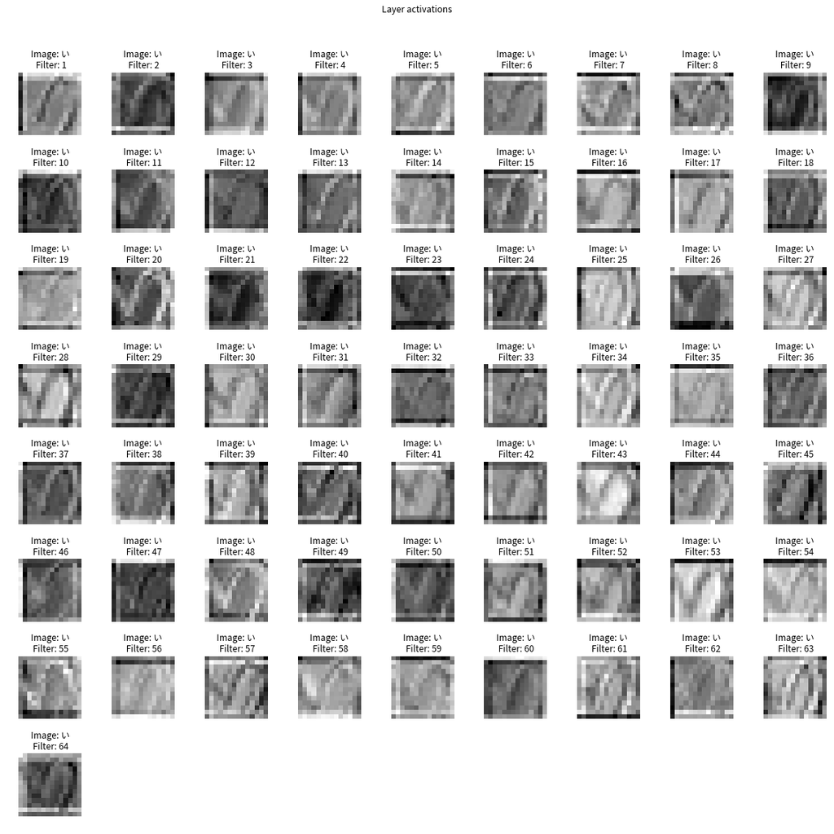

```python
layer_acts = []
rngc = 20
for i in range(1):
    # Select x image activations from layer
    layer_acts.append(conv2_act[i])

display_activations(layer_acts)
```

The results visualization is a mere sample plot for a single batch at present.

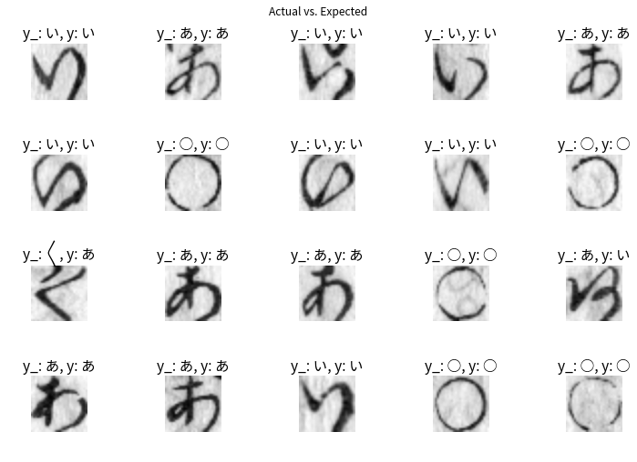

```python
def display_results(chars, preds, acts):
    # Plot results
    with plt.style.context("seaborn-talk"):
        plt.rcParams['font.family'] = 'Noto Sans CJK JP Regular'
        fig = plt.figure()
        fig.suptitle('Actual vs. Expected')
        for rng, idx in zip(range(20), range(20)):
            plt.subplot(4, 5, rng + 1)
            img = test_x[idx]
            plt.imshow(np.reshape(img, [ih, iw]),
                       interpolation="gaussian", cmap="gray")
            plt.title("y_: %s, y: %s" % (chars[acts[idx]],
                                        chars[preds[idx]]))
            plt.axis("off")
        plt.tight_layout()
        plt.subplots_adjust(top=0.9)
        res_img_path = './moji_res_{:s}.png'.format(labels[acts[idx]])
        if i == 0 and not os.path.exists(res_img_path):
            plt.savefig(res_img_path, dpi=150, transparent=False)
        plt.show()

display_results(chars, preds, acts)
```

An attempt at examining the softmax results for the top *k* possibilities for a given image.

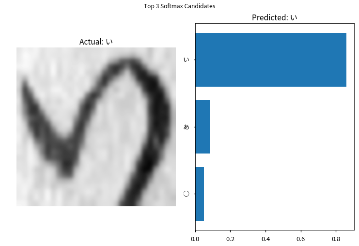

```python
correct = True # Manually toggle which version to look at...
for img_ix in range(batch_size):
    if not correct:
        if labels[acts[img_ix]] != labels[preds[img_ix]]:
            # Select incorrect predictions...
            break
    else:
        if labels[acts[img_ix]] == labels[preds[img_ix]]:
            # Select correct predictions...
            break
k = 3
top_k = [(idx, val) for idx, val in enumerate(sma[0][img_ix])
        if val in heapq.nlargest(k, sma[0][img_ix])]

def get_softmax(top_k, img_ix):
    with plt.style.context("seaborn-talk"):
        plt.rcParams['font.family'] = 'Noto Sans Japanese'
        fig, axes = plt.subplots(1, 2)
        plt.suptitle('Top {:d} Softmax Candidates'.format(len(top_k)))
        img = test_x[img_ix]
        axes[0].imshow(np.reshape(img, [ih, iw]),
                       interpolation="gaussian", cmap="gray")
        axes[0].set_title("Actual: %s" % (chars[acts[img_ix]]))
        axes[0].set_axis_off()
        axes[1].set_title("Predicted: %s" % (chars[preds[img_ix]]))
        axes[1].barh(np.arange(k),
                     [j for i, j in top_k])
        plt.yticks(np.arange(k),
                   [chars[i]
                    for i, j in top_k]) # labels[i] for code points
        fig.tight_layout()
        plt.subplots_adjust(top=0.9)
        soft_img_path = './soft_res_{:s}.png'.format(labels[acts[img_ix]])
        if i == 0 and not os.path.exists(soft_img_path):
            plt.savefig(soft_img_path, dpi=150, transparent=False)
        plt.show()

get_softmax(top_k, img_ix)
```

Below we can view the activated TensorBoard results in the notebook. You can first activate TensorBoard–via the [Jupyter-TensorBoard](https://github.com/lspvic/jupyter_tensorboard) extension–in the Jupyter tree, after selecting a notebook.

```python
# from IPython.display import IFrame
# IFrame('http://localhost:6006', width=980, height=500)
```

🢁